# ANCOVA

Alan T. Arnholt

Last Updated on: Feb 25, 2017 at 10:50:03

Data in the following example are selected from a larger experiment on the use of drugs in the treatment of leprosy (Snedecor and Cochran 1967, p. 422).

```r
DF <- data.frame(Drug = rep(c("A", "D", "F"), each = 10), PreTreatment = c(11,8,5,14,19,6,10,6,11,3,6,6,7,8,18,8,19,8,5,15,16,13,11,9,21,16,12,12,7,12), PostTreatment = c(6,0,2,8,11,4,13,1,8,0,0,2,3,1,18,4,14,9,1,9,13,10,18,5,23,12,5,16,1,20))
DT::datatable(DF)
```

|  | Drug | PreTreatment | PostTreatment |
| --- | --- | --- | --- |
| 1 | A | 11 | 6 |
| 2 | A | 8 | 0 |
| 3 | A | 5 | 2 |
| 4 | A | 14 | 8 |
| 5 | A | 19 | 11 |
| 6 | A | 6 | 4 |
| 7 | A | 10 | 13 |
| 8 | A | 6 | 1 |
| 9 | A | 11 | 8 |
| 10 | A | 3 | 0 |

[output cut: 20 more lines]

View the data

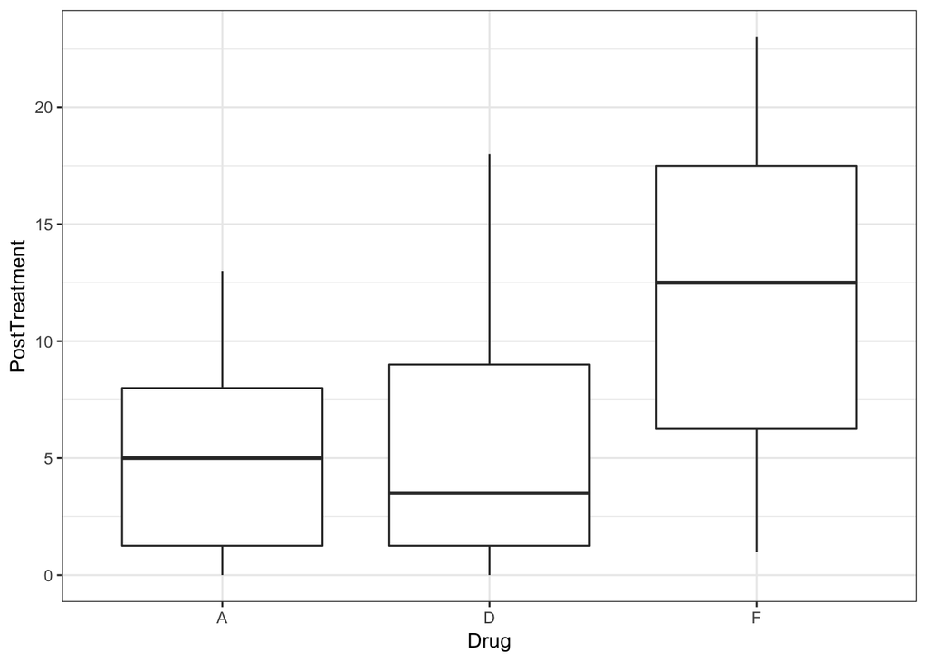

```r
library(ggplot2)
ggplot(data = DF, aes(x = Drug, y = PostTreatment)) +
  geom_boxplot() +
  theme_bw()
```

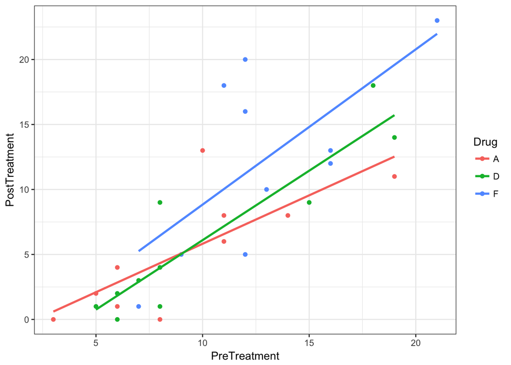

```r
ggplot(data = DF, aes(x = PreTreatment, y = PostTreatment, color = Drug)) +
  geom_point() +
  theme_bw() +
  geom_smooth(method = "lm", se = FALSE)
```

Means

```r
library(dplyr)
DF %>%
  group_by(Drug) %>%
  summarize(MEAN = mean(PostTreatment))
```

```
# A tibble: 3 × 2
    Drug  MEAN
  <fctr> <dbl>
1      A   5.3
2      D   6.1
3      F  12.3
```

```r
mod2 <- lm(PostTreatment ~ Drug, data = DF)
anova(mod2)
```

```
Analysis of Variance Table

Response: PostTreatment
          Df Sum Sq Mean Sq F value  Pr(>F)
Drug       2  293.6 146.800  3.9831 0.03049 *
Residuals 27  995.1  36.856
---
Signif. codes:  0 '***' 0.001 '**' 0.01 '*' 0.05 '.' 0.1 ' ' 1
```

Model

```r
mod <- lm(PostTreatment ~ PreTreatment, data = DF)
summary(mod)
```

```
Call:
lm(formula = PostTreatment ~ PreTreatment, data = DF)

Residuals:
    Min      1Q  Median      3Q     Max
-5.9778 -2.7758 -0.7513  1.1213 10.7091

Coefficients:
             Estimate Std. Error t value Pr(>|t|)
(Intercept)   -3.8865     1.8920  -2.054   0.0494 *
PreTreatment   1.0981     0.1614   6.803 2.17e-07 ***
---
Signif. codes:  0 '***' 0.001 '**' 0.01 '*' 0.05 '.' 0.1 ' ' 1

Residual standard error: 4.165 on 28 degrees of freedom
Multiple R-squared:  0.6231,    Adjusted R-squared:  0.6096
F-statistic: 46.28 on 1 and 28 DF,  p-value: 2.171e-07
```

```r
fullmodel <- lm(PostTreatment ~ PreTreatment*Drug, data = DF)
summary(fullmodel)
```

```
Call:
lm(formula = PostTreatment ~ PreTreatment * Drug, data = DF)

Residuals:
   Min     1Q Median     3Q    Max
-6.225 -2.437 -0.586  1.126  8.775

Coefficients:
                   Estimate Std. Error t value Pr(>|t|)
(Intercept)         -1.6306     2.9455  -0.554   0.5850
PreTreatment         0.7452     0.2849   2.616   0.0152 *
DrugD               -2.9549     4.1246  -0.716   0.4806
DrugF               -1.4780     5.4678  -0.270   0.7892
PreTreatment:DrugD   0.3233     0.3846   0.841   0.4089
PreTreatment:DrugF   0.4492     0.4458   1.008   0.3236
---
Signif. codes:  0 '***' 0.001 '**' 0.01 '*' 0.05 '.' 0.1 ' ' 1

Residual standard error: 4.07 on 24 degrees of freedom
Multiple R-squared:  0.6915,    Adjusted R-squared:  0.6272
F-statistic: 10.76 on 5 and 24 DF,  p-value: 1.63e-05
```

```r
reducedmodel <- lm(PostTreatment ~ PreTreatment + Drug, data = DF)
summary(reducedmodel)
```

```
Call:
lm(formula = PostTreatment ~ PreTreatment + Drug, data = DF)

Residuals:
    Min      1Q  Median      3Q     Max
-6.4115 -2.3891 -0.5711  1.7237  8.5885

Coefficients:
             Estimate Std. Error t value Pr(>|t|)
(Intercept)   -3.8808     1.9862  -1.954   0.0616 .
PreTreatment   0.9872     0.1645   6.001 2.45e-06 ***
DrugD          0.1090     1.7951   0.061   0.9521
DrugF          3.4461     1.8868   1.826   0.0793 .
---
Signif. codes:  0 '***' 0.001 '**' 0.01 '*' 0.05 '.' 0.1 ' ' 1

Residual standard error: 4.006 on 26 degrees of freedom
Multiple R-squared:  0.6763,    Adjusted R-squared:  0.6389
F-statistic:  18.1 on 3 and 26 DF,  p-value: 1.501e-06
```

```r
anova(reducedmodel)
```

```
Analysis of Variance Table

Response: PostTreatment
             Df Sum Sq Mean Sq F value    Pr(>F)
PreTreatment  1 802.94  802.94 50.0393 1.639e-07 ***
Drug          2  68.55   34.28  2.1361    0.1384
Residuals    26 417.20   16.05
---
Signif. codes:  0 '***' 0.001 '**' 0.01 '*' 0.05 '.' 0.1 ' ' 1
```

```r
anova(reducedmodel, fullmodel)
```

```
Analysis of Variance Table

Model 1: PostTreatment ~ PreTreatment + Drug
Model 2: PostTreatment ~ PreTreatment * Drug
  Res.Df    RSS Df Sum of Sq     F Pr(>F)
1     26 417.20
2     24 397.56  2    19.645 0.593 0.5606
```

```r
anova(mod, reducedmodel)
```

```
Analysis of Variance Table

Model 1: PostTreatment ~ PreTreatment
Model 2: PostTreatment ~ PreTreatment + Drug
  Res.Df    RSS Df Sum of Sq      F Pr(>F)
1     28 485.76
2     26 417.20  2    68.554 2.1361 0.1384
```

Least Squares Means

```r
library(lsmeans)
lsmeans(reducedmodel, "Drug")
```

```
 Drug    lsmean       SE df lower.CL  upper.CL
 A     6.714963 1.288494 26 4.066426  9.363501
 D     6.823935 1.272469 26 4.208337  9.439532
 F    10.161102 1.315923 26 7.456182 12.866021

Confidence level used: 0.95
```

## New Example

Experiments were carried out on six commercial goat farms to determine whether the standard worm drenching program was adequate. Forty goats were used in each experiment. Twenty of these, chosen completely at random, were drenched according to the standard program, while the remaining twenty were drenched more frequently. The goats were individually tagged, and weighed at the start and end of the year-long study. For the first farm in the study the resulting liveweight gains are given along with the initial liveweights. In each experiment the main interest was in the comparison of the liveweight gains between the two treatments. This comparison could be made using an ANOVA. However, a commonly observed biological phenomenon allows us to increase the precision of the analysis. This is the phenomenon of “regression to the norm”, which in our instance means that the lighter animals gain more weight than the heavier animals. Since this can be assumed to occur within both treatment groups, it is appropriate to use ANCOVA to fit two parallel lines to the data, as shown in Figure 1. The corresponding ANCOVA comparison of adjusted mean liveweight gains will in general be more sensitive than the ANOVA comparison of unadjusted mean liveweight gains.

```r
site <- "http://www.statlab.uni-heidelberg.de/data/ancova/goats.data"
DF2 <- read.table(site, skip = 1, col.names = c("Treatment", "WeightGain", "InitialWeight"))
DF2 %>%
  group_by(Treatment) %>%
  summarize(AVG = mean(WeightGain), SD = sd(WeightGain))
```

```
# A tibble: 2 × 3
  Treatment   AVG       SD
     <fctr> <dbl>    <dbl>
1 intensive  6.85 1.980829
2  standard  5.55 2.064104
```

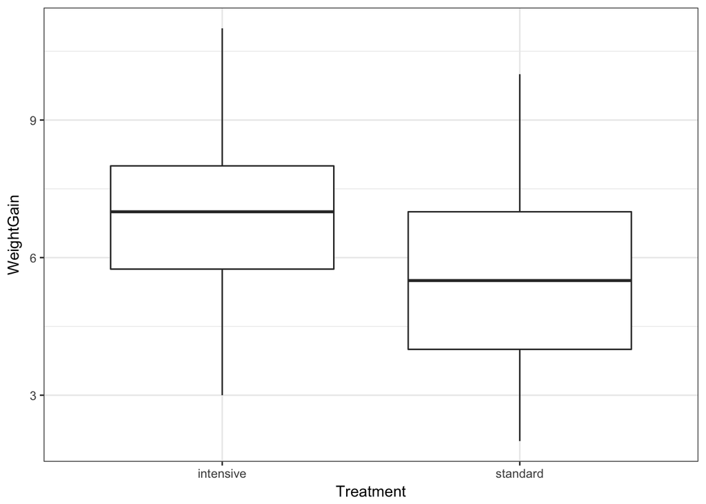

```r
ggplot(data = DF2, aes(x = Treatment, y = WeightGain)) +
  geom_boxplot() +
  theme_bw()
```

```r
mod <- lm(WeightGain ~ Treatment, data = DF2)
summary(mod)
```

```
Call:
lm(formula = WeightGain ~ Treatment, data = DF2)

Residuals:
   Min     1Q Median     3Q    Max
 -3.85  -1.55   0.15   1.15   4.45

Coefficients:
                  Estimate Std. Error t value Pr(>|t|)
(Intercept)         6.8500     0.4523  15.144   <2e-16 ***
Treatmentstandard  -1.3000     0.6397  -2.032   0.0492 *
---
Signif. codes:  0 '***' 0.001 '**' 0.01 '*' 0.05 '.' 0.1 ' ' 1

Residual standard error: 2.023 on 38 degrees of freedom
Multiple R-squared:  0.09803,   Adjusted R-squared:  0.07429
F-statistic:  4.13 on 1 and 38 DF,  p-value: 0.04916
```

```r
anova(mod)
```

```
Analysis of Variance Table

Response: WeightGain
          Df Sum Sq Mean Sq F value  Pr(>F)
Treatment  1   16.9 16.9000  4.1299 0.04916 *
Residuals 38  155.5  4.0921
---
Signif. codes:  0 '***' 0.001 '**' 0.01 '*' 0.05 '.' 0.1 ' ' 1
```

New Graph

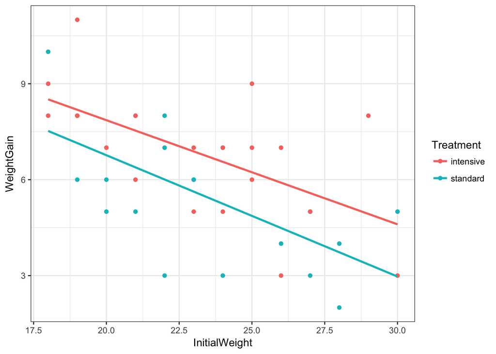

```r
ggplot(data = DF2, aes(x = InitialWeight, y = WeightGain, color = Treatment)) +
  geom_point() +
  geom_smooth(method = "lm", se = FALSE) +
  theme_bw()
```

```r
mod2 <- lm(WeightGain ~ Treatment + InitialWeight, data = DF2)
mod3 <- lm(WeightGain ~ Treatment * InitialWeight, data = DF2)
anova(mod2, mod3)
```

```
Analysis of Variance Table

Model 1: WeightGain ~ Treatment + InitialWeight
Model 2: WeightGain ~ Treatment * InitialWeight
  Res.Df    RSS Df Sum of Sq      F Pr(>F)
1     37 96.857
2     36 96.514  1   0.34225 0.1277  0.723
```

```r
summary(mod2)
```

```
Call:
lm(formula = WeightGain ~ Treatment + InitialWeight, data = DF2)

Residuals:
    Min      1Q  Median      3Q     Max
-2.9716 -1.2419 -0.0338  0.9878  3.2231

Coefficients:
                  Estimate Std. Error t value Pr(>|t|)
(Intercept)       14.96661    1.75261   8.540 2.82e-10 ***
Treatmentstandard -1.26486    0.51169  -2.472   0.0182 *
InitialWeight     -0.35137    0.07424  -4.733 3.21e-05 ***
---
Signif. codes:  0 '***' 0.001 '**' 0.01 '*' 0.05 '.' 0.1 ' ' 1

Residual standard error: 1.618 on 37 degrees of freedom
Multiple R-squared:  0.4382,    Adjusted R-squared:  0.4078
F-statistic: 14.43 on 2 and 37 DF,  p-value: 2.331e-05
```

## Draw the lines properly now!

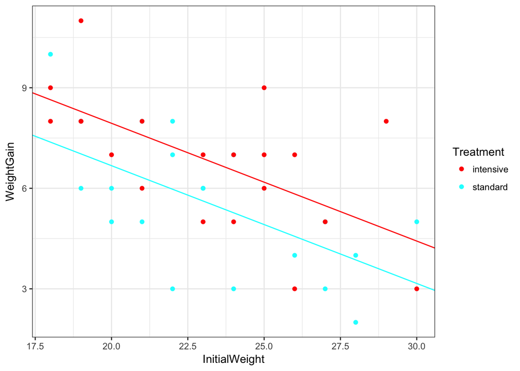

Figure 1: Correct One

```r
ggplot(data = DF2, aes(x = InitialWeight, y = WeightGain, color = Treatment)) +
  geom_point() +
  theme_bw() +
  geom_abline(intercept = coef(mod2)[1] + coef(mod2)[2], slope = coef(mod2)[3], color = "cyan") +
  geom_abline(intercept = coef(mod2)[1], slope = coef(mod2)[3], color = "red") +
  scale_color_manual(values = c("red", "cyan"))
```

## LS Means

```r
DF2 %>%
  group_by(Treatment) %>%
  summarize(AVG = mean(WeightGain), SD = sd(WeightGain))
```

```
# A tibble: 2 × 3
  Treatment   AVG       SD
     <fctr> <dbl>    <dbl>
1 intensive  6.85 1.980829
2  standard  5.55 2.064104
```

```r
lsmeans(mod2, "Treatment")
```

```
 Treatment   lsmean        SE df lower.CL upper.CL
 intensive 6.832432 0.3618026 37 6.099350 7.565513
 standard  5.567568 0.3618026 37 4.834487 6.300650

Confidence level used: 0.95
```